# DeepLearningCausal: R Package for Estimating Treatment Effects Using Deep Neural Networks and Ensemble Learning

Conventional machine learning (ML) methods for causal inference are widely used for estimating causal effects and uncovering heterogeneous treatment effects. Yet, deep learning, which leverages deep neural networks to address selection bias and unobserved confounders, is underutilized for estimating sample and population average treatment effects. Further, conventional ML methods are employed to estimate treatment effects under the assumption that all units in the sample comply with the treatment, which is often implausible. To address these methodological challenges, this article introduces our DeepLearningCausal R-package that enables users to employ deep neural networks to estimate conditional average treatment effects (CATEs) from samples via meta-learners and population average treatment effects on the treated (PATT) in settings with treatment noncompliance. DeepLearningCausal also includes functions to compute and illustrate conformal prediction (CP) intervals for the estimated meta-learner individual treatment effects (ITEs), visualize heterogeneous treatment effects, and estimate CATEs and PATT by using weighted ensemble learning.

Nguyen Khoi Huynh (Hitotsubashi Institute for Advanced StudyHitotsubashi University) , Yang Yang (Department of Political ScienceThe Pennsylvania State University) , Bumba Mukherjee (Department of Political ScienceThe Pennsylvania State University)  
2026-07-19

## 1 Introduction

Causal inference constitutes a vital component of scientific research in biology, economics, epidemiology, medicine, political science, and sociology (Pearl 2009; Imbens and Rubin 2015; Athey and Imbens 2016; Li et al. 2024). Many puzzles in the natural and social sciences are causal questions and answers to these questions are statistically evaluated by estimating conditional average treatment effects (CATE) obtained from randomized control trials or (structural) causal models estimated on experimental and observational samples (Hill 2011; Yao et al. 2018; Hu et al. 2021; Tikka 2023). Yet the following methodological challenges often impede the accuracy of treatment effects estimated from samples: unobserved confounders, high-dimensional data, low external validity to the target population, and complex non-linear relationships between the treatment and outcome measures.

To address these challenges, scholars use conventional machine learning (ML) algorithms such as causal trees (Athey and Imbens 2016), kernel methods (Alaa and Van Der Schaar 2018), or causal boosting (Powers et al. 2018) that capture complex non-linear relationships when estimating treatment effects. Others have used targeted learning which leverages the Super Learner approach for estimating targeted causal estimands (Laan and Rose 2011; Schuler and Rose 2019). Researchers have also accounted for unobserved confounders by developing *meta-learner* models that tackle the said issue by decomposing estimation of CATEs into multiple sub-problems solved by conventional ML methods (Künzel et al. 2019; Nie and Wager 2021). Some scholars have addressed external validity by extending the generalizability of sample treatment effects to the target population by using standard ML methods to estimate population average treatment effects on the treated from experimental and observational data (Hartman et al. 2015; Balzer et al. 2016; Zhang et al. 2019; Ottoboni and Populos 2020). These statistical learning approaches that employ machine learning for causal inference have been widely disseminated via software packages that are discussed in the next section.

But unlike the widespread use of standard ML algorithms for causal inference, deep learning methods have been underutilized for the estimation of not just sample treatment effects such as CATEs but also population average treatment effects. This is surprising as deep learning methods based on deep neural networks capture heterogeneous treatment effects with low bias, account for unobserved confounders and selection bias, and assess causality in complex settings (Farrell et al. 2021; Koch et al. 2024). Moreover, the aforementioned statistical learning approaches are applied to settings which assume that all individual units in the experimental and observational sample have fully complied with the assigned treatment, even though some units (in reality) neither comply with nor accept the treatment. Not addressing treatment noncompliance of this sort leads to biased results when generalizing estimated treatment effects from samples to the broader target population.

We thus present our R package DeepLearningCausal (available at https://cran.r-project.org/package=DeepLearningCausal) in this paper which overcomes these limitations and enables researchers to employ deep learning methods to estimate CATEs from samples and population average treatment effects on the treated (PATT) from data that exhibit treatment noncompliance. DeepLearningCausal allows users to employ deep learning based on deep neural networks to estimate CATEs from four meta-learner models: T-learner, S-learner, X-learner, and R-learner. Our package also provides functions to use deep neural networks to estimate the PATT from a newly developed causal model that addresses treatment noncompliance by some units in the sample. Further, DeepLearningCausal provides an interface to Python that enables users to leverage Python’s extensive deep learning ecosystem (within their R script) for estimating the CATE and PATT via deep neural networks. The package provides users with substantial flexibility to substantially customize their deep neural network architecture for deep learning estimation, and enables users to conduct conformal inference of individual treatment effects obtained from the meta-learner models. The analysis presented below primarily focuses on our package’s functionality for *deep learning estimation* of the meta-learner CATEs and the PATT (given treatment noncompliance) using reticulate(Ushey et al. 2025), tensorflow (Abadi et al. 2015; Allaire and Tang 2024), and keras3 (Chollet et al. 2015; Kalinowski et al. 2025) which provide access to Python’s deep learning libraries. The functions and procedure for estimating the meta-learner CATEs and PATT using weighted ensemble learning and R neural nets are provided in our package’s GitHub repository: hknd23/DeepLearningCausal.

## 2 Background and other R packages

Although parametric models are often used for estimating average treatment effects, they rely on the assumption that the functional form of the relationship between variables is correctly specified. But if the assumed model is misspecified, the estimates can be biased, and identification of causal effects can be challenging in the presence of unmeasured confounders (Jonzon et al. 2023; Tikka 2023). Scholars have thus used conventional machine learning methods (e.g., gradient boosting, random forests) to address the aforementioned challenge when estimating CATEs in samples or the PATT in the target population, and one recent study uses deep learning for estimating CATEs from two meta-learner models (Hartman et al. 2015; Johansson et al. 2016; Chernozhukov et al. 2018; Yao et al. 2018; Künzel et al. 2019; Zhang et al. 2020; Koch et al. 2024). Deep learning techniques for causal inference that address challenges such as unstructured variables, unobserved confounders, or unknown intervention include either the use of *general* deep neural networks that involve using multilayer perceptrons or *specific* deep neural network architectures including convolutional neural networks and variational autoencoders (Goodfellow et al. 2016; Koch et al. 2024). Other studies have implemented “targeted learning” that employs super learner-based weighted ensemble learning to estimate specific causal parameters (estimands) by *targeting* the data-fitting process to the target parameter (Laan and Rose 2011; Schuler and Rose 2019).

Conventional ML, targeted learning, and deep learning methods for estimating causal effects address the limitations of parametric models as these methods learn complex relationships without requiring explicit functional forms for the association between variables (Zhang et al. 2020; Nie and Wager 2021; Hu and Ji 2022; Okasa 2022). Given these advantages, it is not surprising that conventional ML or super learner methods are employed for estimating various causal models, including Augmented Inverse Probability Weighting, Double/Debiased Machine Learning, causal estimands that employ targeted learning, and meta-learner models (Glynn and Quinn 2010; Laan and Rose 2011; Chernozhukov et al. 2018; Knaus 2022; Okasa 2022; Bach et al. 2024). While the review by Koch et al. (2024) introduces deep learning for causal effect estimation in the social sciences, researchers also use standard ML methods to estimate population average treatment effects on the treated from experimental data with and without treatment noncompliance (Hartman et al. 2015; Balzer et al. 2016; Ottoboni and Populos 2020).

In line with these trends in the causal machine learning literature, numerous R packages have been developed that permit users to use machine learning methods for causal inference. The package DoubleML Bach et al. (2024) focuses on estimation of the nuisance parts in causal models by machine learning methods and computation of the Neyman orthogonal score functions, while lmtp by Dı́az et al. (2021) employs ensemble learning for estimating causal effects based on longitudinal treatment indicators. The CIMTx package by Hu and Ji (2022) uses Bayesian additive regression trees to estimate multiple treatments with a focus on binary outcomes, and the package causaloptim Jonzon et al. (2023) focuses on causal graphs and bounds for causal inference that have implications for machine learning model development. The SVMMatch package by Ratkovic (2015) uses support vector machines for causal effect estimation, the htetree package by Xu et al. (2023) provides functions to estimate heterogeneous treatment effects with tree-based machine learning algorithms, and twangContinuous by Coffman and Griffin (2021) uses gradient boosting machines for estimating continuous treatments. Python packages such as *CausalML* by Zhao and Liu (2023) and *EconML* by Battocchi et al. (2019) also provide ML methods for estimating treatment effects. There also exists open-source R code that uses ML methods for estimating meta-learner models (Künzel et al. 2019; Nie and Wager 2021).

To our knowledge, our DeepLearningCausal package is the first that allows users to employ deep learning based on deep neural networks to estimate CATEs from several meta-learner models *and* the PATT from a new estimator that accounts for treatment noncompliance by some units (Ottoboni and Populos 2020). DeepLearningCausal also permits users to automatically install the reticulate R package, TensorFlow, and Keras3 (R and Python packages) to integrate Python code and libraries used for deep neural networks within an R environment. This feature enables estimation of treatment effects via a highly customized deep neural network architecture using cutting-edge optimizers such as Adam and RMSprop. Further, our package permits users to implement the recently developed conformal prediction (CP) framework to conduct inference of target parameters such as individual treatment effects from meta-learner models. Additional functions in our package permit estimation of the CATE and PATT via the Super Learner-based weighted ensemble learning, illustration of heterogeneous treatment effects, and assessment of correlation of CATEs from meta-learner models.

## 3 Models

We use the Neyman-Rubin potential outcomes framework to conceptualize estimation of the CATEs and the PATT (Imbens and Rubin 2015). Assume the dataset $\mathcal{D}{\left(Y_{i},\mathbf{X}_{i},W_{i}\right)}_{i=1}^{n}$ with $\left(Y_{i},\mathbf{X}_{i},W_{i}\right)\overset{i.i.d}{\backsim}\mathcal{P}$ where $i$ denotes an individual subject, $Y\in\mathcal{Y}$ is a binary or continuous outcome of interest, $\mathbf{X}_{i}\in\mathcal{X}\subset\mathbb{R}^{d}$ is the vector of covariates, and $W_{i}\in\{0,1\}$ is the binary treatment assigned according to the propensity score $\pi\left(\mathbf{x}\right)=P\left(W_{i}=1|\mathbf{X}_{i}=\mathbf{x}\right)$. The two potential outcomes (POs) represent the outcome under the treatment $Y_{i}^{\left(1\right)}$ and control $Y_{i}^{(0)}$. Since only one of the POs is observed, the observed outcome is: $Y=W_{i}Y_{i}^{\left(1\right)}+\left(1-W_{i}\right)Y_{i}^{\left(0\right)}$. The ATE is the difference between the two POs: $\tau=E\left[Y_{i}^{\left(1\right)}-Y_{i}^{\left(0\right)}\right]$. The ATE is *identifiable* when the following assumptions hold: consistency, SUTVA (Stable Unit Treatment Value Assumption), ignorability (POs are independent of the treatment assignment given the covariates), and positivity (each *i* has a non-zero probability of belonging to the control and treated groups). These assumptions also permit identification of the CATEs defined below.

### 3.1 CATEs and non-parametric regression framework

Given *identifiability*, the conditional average treatment effect (CATE) is the expected difference between the two POs conditional on the covariates $\mathbf{X}_{i}=\mathbf{x}$:
$$\begin{equation}
\tau\left(\mathbf{x}\right)=\mathbb{E}\left[Y_{i}^{\left(1\right)}-Y_{i}^{\left(0\right)}|{\mathbf{X}_{i}}=\mathbf{x}\right]=\mu_{1}\left(\mathbf{x}\right)-\mu_{0}\left(\mathbf{x}\right)
\end{equation}$$
Equation (1) reveals that the CATE is defined as the difference between the response surface under treatment, $\mu_{1}\left(\mathbf{x}\right)$, and under control, $\mu_{0}\left(\mathbf{x}\right)$:
$$\begin{equation}
\mu_{w}\left(\mathbf{x}\right):=\mathbb{E}\left[Y^{(w)}|\mathbf{X}_{i}=\mathbf{x}\right]
\end{equation}$$
While the CATE can be estimated via numerous methods, we focus below on *meta-learners* which are non-parametric regression approaches that model the outcome surface $Y$ as a function of the treatment assignment $W_{i}$, the covariates $\mathbf{X}_{i}$, and the error term $\varepsilon_{i}$: $Y=f\left(\mathbf{X}_{i}, W_{i}\right)+\varepsilon_{i}$ where $\varepsilon_{i}\sim N\left(0,\sigma^{2}\right)$ and $f\left(\mathbf{X}_{i}, W_{i}\right)=\mathbb{E}\left[Y|\mathbf{X}_{i},W_{i}\right]$. We turn to describe the four meta-learner models that estimate the CATE via the non-parametric regression framework: T-learner, S-learner, X-learner, and R-learner.

### 3.2 Meta-learner models: T-learner and S-learner

Meta-learner models decompose estimation of the CATE $\hat{\tau}\left(\mathbf{x}\right)$ into multiple prediction problems (Künzel et al. 2019). The machine or deep learning method employed to solve the prediction problem is called a *base-learner*. Most of the prediction problems in meta-learner models amount to estimating the conditional means of the outcome and the treatment. The latter are referred to as *nuisance* functions, because they are not of primary interest themselves, but are needed to derive $\hat{\tau}\left(\mathbf{x}\right)$. Meta-learner models are typically categorized into *conditional mean regression* and *pseudo-outcome* methods (Okasa 2022). We thus formally describe two main conditional mean regression methods (T and S-learner models) and then turn to present two key pseudo-outcome methods (X and R-learner models).

To begin with, the T-learner model estimates $\tau\left(\mathbf{x}\right)$ by estimating the conditional mean function in each treatment arm, $\mu_{0}\left(\mathbf{x}\right)=\mathbb{E}\left[ Y|\mathbf{X}_{i}=\mathbf{x}, W_{i}=0\right]$, and the conditional mean function under treatment, $\mu_{1}\left(\mathbf{x}\right)=\mathbb{E}\left[ Y|\mathbf{X}_{i}=\mathbf{x}, W_{i}=1 \right]$. Accordingly, the T-learner estimates the CATE by fitting two separate response surfaces for the treated and control groups respectively, and then computing their difference:
$$\begin{equation}
\widehat{\tau}\left(\mathbf{x}\right)=\widehat{\mu}_{1}\left(\mathbf{x}\right)-\widehat{\mu}_{0}\left(\mathbf{x}\right)
\end{equation}$$
This task is implemented by fitting two separate prediction models for the base learner: the first to the control group’s data and the second to the treatment group’s data. The base learner can be fitted by weighted ensemble learning or deep neural networks which we focus on below. Specifically, deep neural network (DNN-)estimated CATEs from the T-learner model are obtained by using feed-forward networks. This entails fitting a separate network for each regression task, namely the PO surface for the treated, $\mu_{1}$, and the control, $\mu_{0}$, groups. The two networks are trained using,

$$\begin{equation}
\mathcal{L}_{F}+\lambda\sum\limits_{1}^{n_w}\Re\left(\Theta_{\mu_{W}}\right)
\end{equation}$$
$\mathcal{L}_{F}$ is the loss function of the general penalized objective function, $\mathcal{\mathcal{\Re}}\left(.\right)$ is the regularization term, $\Theta_{\mu_{W}}$ is the network’s weights where $W_{i}\in\left(0,1\right)$, and $\lambda$ is the hyperparameter that controls the trade-off between the standard loss and regularization term. Once the two POs surfaces are estimated, CATEs from the DNN-estimated T-learner are obtained by the difference: $\widehat{\tau}\left(\mathbf{x}\right)=\widehat{\mu}_{1}\left(\mathbf{x}\right)-\widehat{\mu}_{0} \left(\mathbf{x}\right)$. This means that DNN-estimation of the T-learner fits the response variable $Y$ by assuming that the response surfaces $\mu_{w}$ are group-specific, and thus dependent on different conditional means $f_{w}\left(.\right)$ and error terms $\varepsilon_{w}$. The pseudocode for the DNN-estimated T-learner is:

| **Algorithm:** DNN-estimated T-learner |
| --- |
| **Input:** **X**, *Y*, *W*; **Output:** $\widehat{\tau}$ |
| 1: $\widehat{\mu}_{0}=NN_{1}\left(Y^{0}\sim\mathbf{X}^{0}\right)$ $\triangleright$ Estimate POs surfaces |
| 2: $\widehat{\mu}_{1}=NN_{2}\left(Y^{1}\sim\mathbf{X}^{1}\right)$ |
| 3: $\widehat{\tau}\left(\mathbf{x}\right)=\widehat{\mu}_{1}(\mathbf{x})-\widehat{\mu}_{0}(\mathbf{x})$ $\triangleright$ Estimate CATE |

where $NN_{1}$ denotes deep neural networks. The S-learner uses the whole sample to fit a single model in which the observed outcome values are modeled as a function of the covariates and the treatment to obtain $\widehat{\mu} \left(\mathbf{x},w\right)=\hat{\mathbb{E}}\left[Y|\mathbf{X}_{i} = \mathbf{x}; W_{i}=w\right].$ Hence, the S-learner’s CATEs are estimated as,

$$\begin{equation}
\widehat{\tau}\left(\mathbf{x}\right)=\widehat{\mu}\left(\mathbf{x},1\right)-\widehat{\mu}\left(\mathbf{x},0\right)
\end{equation}$$

This expression implies that the S-Learner fits a single response surface $\mu\left(.\right)$ by using regressors $\left(\mathbf{X}_{i}, W_{i}\right)$ through a base learner and estimates CATEs by taking the difference between the two conditional average POs represented by the fitted $\widehat{\mu}\left(.\right)$ with $W_{i}=1$ and $W_{i}=0$. The group-specific conditional average POs in the S-learner stem from the same model, with conditional mean function $\mu\left(.\right)$ and error term $\varepsilon_{i}$. Formally, the deep neural network-based (DNN-based) S-learner uses feed-forward networks to fit a separate network for the regression task, namely the single response surface. This network is trained by using the general loss function defined above. Once the response surface is estimated, the DNN-based S-learner obtains the CATE by the difference stated in equation (5). The pseudocode for estimating the DNN-based S-learner is:

| **Algorithm:** DNN-estimated S-learner |
| --- |
| **Input:** **X**, *Y*, *W*; **Output:** $\widehat{\tau}$ |
| 1: $\widehat{\mu}=NN_{1}\left(Y\sim \left(X,W\right)\right)$ $\triangleright$ Estimate response surface |
| 2: $\widehat{\tau}\left(\mathbf{x}\right)=\widehat{\mu}\left(x,1\right)-\widehat{\mu}\left(x,0\right)$ $\triangleright$ Estimate CATE |

### 3.3 Individual Treatment Effects (ITEs) and conformal prediction

Existing studies have primarily focused on machine learning algorithms or (less frequently) deep learning to produce point estimates of CATEs from meta-learner models, which quantify the expected difference in treatment outcomes for individuals with specific characteristics (Künzel et al. 2019; Wager and Athey 2019). While CATEs account for different covariates by averaging effects across similar individuals, it tends to overlook individual-level heterogeneity. Recent studies have addressed this issue by focusing on individual treatment effects (ITEs) that offer more accurate predictions tailored to each individual (Alaa and Van Der Schaar 2018).

Building on this, our package permits users to apply the recently developed work on weighted split conformal quantile regression (CQR) for producing conformal prediction (CP) intervals for ITEs obtained from the said meta-learner models (Lei and Candès 2021; Alaa et al. 2023). The CQR framework that integrates the concept of conformal prediction with quantile regression enables direct inference of the target parameters (ITEs) obtained in the two conditional mean regression methods: the S-learner and T-learner model.

Weighted conformal prediction provides a model-agnostic and distribution-free framework that produces interval predictions with the desired coverage probability. The main idea of (split) conformal prediction is to compute a conformity score by fitting a predictive model on the training set and then evaluating the conformity score on the calibration set to quantify the uncertainty of future predictions. Doing so allows researchers to estimate and construct intervals of ITEs by computing the empirical quantile of conformity scores evaluated in a held-out calibration set. We turn to briefly present below how we employ the weighted split CQR framework to estimate and construct CP intervals for the S-learner model’s ITEs. The CQR framework for estimating and constructing CP intervals for the T-learner’s ITEs is summarized in the GitHub repository of our package.

To this end, recall that the meta-learner CATEs are defined as $\tau\left(\mathbf{x}\right)=\mathbb{E}\left[Y_{i}^{\left(1\right)}-Y_{i}^{\left(0\right)}|{\mathbf{X}_{i}}=\mathbf{x}\right]$. Our focus is to employ the weighted split CQR procedure to estimate and construct valid prediction intervals $\widehat{C}_{1-\alpha}(x_{i})$ for the S-learner’s ITEs: $\widehat{\tau}(x_{i})=\widehat{Y}_{i}(1)-\widehat{Y}_{i}(0)$ where $\widehat{Y}_{i}(1)$ and $\widehat{Y}_{i}(0)$ are predicted potential outcomes under treatment and control, respectively. The algorithm for doing so is summarized as:

[output not shown]

### 3.4 X-learner and R-learner (meta-learner) models

| **Algorithm:** DNN-estimated X-learner |
| --- |
| **Input:** **X**, *Y*, *W*, *g; **Output:** $\widehat{\tau}$ |
| 1:$\widehat{\mu}_{0}=NN_{1}\left(Y^{0}\sim\mathbf{X}^{0}\right)$ $\triangleright$ Estimate response surfaces |
| 2:$\widehat{\mu}_{1}=NN_{2}\left(Y^{1}\sim\mathbf{X}^{1}\right)$ |
| 3:$\tilde{D}^{1}=Y^{1}-\widehat{\mu}_{0}\left(\mathbf{X}^{1}\right)$ $\triangleright$ Compute imputed treatment effects |
| 4:$\tilde{D}^{0}=\widehat{\mu}_{1}\left(\mathbf{X}^{0}\right)-Y^{0}$ |
| 5:$\widehat{\tau}_{1}=NN_{3}\left(\tilde{D}^{1}\sim\mathbf{X}^{1}\right)$ $\triangleright$ Estimate group-specific CATEs |
| 6: $\widehat{\tau}_{0}=NN_{4}\left(\tilde{D}^{0}\sim\mathbf{X}^{0}\right)$ |
| 7: $\hat{\tau}(\mathbf{x})=g(\mathbf{x})\hat{\tau}_0(\mathbf{x})+\left(1-g(\mathbf{x})\right)\hat{\tau}_1(\mathbf{x})$ $\triangleright$ Average estimates |

Next, consider Nie and Wager (2021)’s R-learner model that uses a specific loss function to capture treatment effect heterogeneity. Minimizing this loss function is equivalent to fitting a weighted pseudo-outcome regression. The R-learner starts with estimating the covariate-specific propensity function $\pi\left(\mathbf{X}_{i}\right)=Pr(W_{i}=1|\mathbf{X}_{i})$ for $W_{i}=1$, and the conditional mean of the outcome $Y_{i}$ given the covariates $\mathbf{X}_{i}$: $m\left(\mathbf{X}_{i}\right)=E\left[Y|\mathbf{X}_{i} = x\right]$. The R-learner’s CATEs are then obtained by minimizing
$$\begin{equation}
\widehat{\mathcal{L}}_{R}\left[\tau\left(.\right)\right]=\frac{1}{n}\sum_{i=1}^{n}(W_{i}-\widehat{\pi}\left(\mathbf{X}_{i}\right))^{2}\left[\frac{Y_{i}-\widehat{m}\left(\mathbf{X}_{i}\right)}{W_{i}-\widehat{\pi}\left(\mathbf{X}_{i}\right)}-\tau\left(\mathbf{X}_{i}\right)\right]^{2}
\end{equation}$$
$$\begin{equation}
=\frac{1}{n}\sum_{i=1}^{n}\left(W_{i}-\widehat{\pi}\left(\mathbf{X}_{i}\right)\right)^{2}\left[\widehat{\psi}_{R}\left(\mathbf{X}_{i}\right)-\tau \left(\mathbf{X}_{i}\right)\right]^{2}
\end{equation}$$
Equation (11) implies that minimizing the loss function is equivalent to regressing the pseudo-outcome $\widehat{\psi}_{R}\left(\mathbf{X}_{i}\right)$ on the observed covariates weighted by $(W_{i}-\widehat{\pi}\left(\mathbf{X}_{i}\right))^{2}$. The pseudo-outcome is motivated by a semiparametric linear model that uses residuals from the regression of $Y_{i}$ on $X_{i}$ (i.e., $Y_{i}-m\left(\mathbf{X}_{i}\right)$) and the residuals from the regression of $W_{i}$ on $\mathbf{X}_{i}$ to address potential confounding from $\mathbf{X}_{i}$.

The R-learner’s CATEs are estimated via the weighted pseudo-outcome regression as follows. First, after splitting the data into *k-*folds, fit the nuisance functions $\widehat{m}\left(.\right)$ and $\widehat{\pi}\left(.\right)$ on the portion of the excluded data by minimizing the prediction errors via cross-validation. Second, plug in the estimates from the previous step to estimate $\hat{\tau}(\mathbf{x_{i}})$ by minimizing (11) via parameter tuning on the *k-*folds. The weighted pseudo-outcome regression can be fit by deep neural networks (or weighted ensemble learning) that allow modification of the loss function by passing the weights $(W_{i}-\widehat{\pi}\left(\mathbf{X}_{i}\right))^{2}$. The pseudocode for obtaining CATEs from the deep neural network-estimated R-learner is:

| **Algorithm:** DNN-estimated R-learner |
| --- |
| **Input:** **X**, *Y*, *W*; **Output:** $\widehat{\tau}$ |
| 1: $\widehat{m}=NN_{1}(Y\sim\mathbf{X})$ $\triangleright$ Estimate *nuisance* parameters |
| 2: $\widehat{\pi}=NN_{2}(W\sim\mathbf{X})$ |
| 3: $\widehat{\psi}_{R}\left(\mathbf{X}_{i}\right)=\frac{Y_{i}-\widehat{m}\left(\mathbf{X}_{i}\right)}{(W_{i}-\widehat{\pi}\left(\mathbf{X}_{i}\right)}$ $\triangleright$ Compute pseudo-outcome |
| 4: $\hat{\tau}=NN_{3}(\widehat{\psi}_{R}\sim\mathbf{X}_{i})$ $\triangleright$ Estimate CATE |

### 3.5 Estimating PATT from experiments with noncompliance

Scholars such as Ottoboni and Populos (2020) have developed the “PATT-C” model to obtain *population* average treatment effects on the treated (PATT) from experimental (e.g., RCTs) and observational samples in which noncompliance with treatment is prevalent. We focus here on presenting the PATT-C model. To this end, let $Y_{iGR}$ be the potential outcome for individual $i$ in group $G_{i}\in\{0,1\}.$ $G=0$ in $Y_{iGR}$ when $i$ is in the target population and $G=1$ when $i$ is in the experimental sample (e.g. RCT).

Define $W_{i}\in\{0,1\}$ as the binary treatment assignment. Let $R_{i}\in\{0,1\}$ denote whether or not $i$ received the treatment. Because the treatment is randomly assigned in the experimental sample, $W_{i}$ and $R_{i}$ are observed in this sample when $G_{i}=1$ for $i$. Let $X_{i}\in\{0,1\}$ be the pretreatment covariates that influence selection into the experimental sample, treatment assignment in the population, and treatment noncompliance. $W_{i}=0$ for individuals in the population who do not receive the treatment. $W_{i}=1$ for those who receive the treatment but can decide whether or not to accept the treatment.

Let $C_{i}\in\{0,1\}$. $C_{i}=1$ when $i$ complies with the received treatment, and $C_{i}=0$ when $i$ does not comply with the treatment. $C_{i}$ is only observed for individuals in the treated group in the experimental sample. Hence, for individuals who comply with the treatment, $W_{i}=R_{i}$. For individuals in the population, we only observe $R_{i}$ but not $W_{i}$. Five assumptions permit identification of PATT from experimental samples with treatment noncompliance (Ottoboni and Populos 2020 110). The first assumption is *consistency* which implies that each $i$ has the same response to the received treatment whether or not $i$ is in the experimental sample: $Y_{i0R}=$ $Y_{i1R}$; $R=\{0,1\}$ $\forall i.$ The second is *conditional independence* of compliance and sample and treatment assignment: $C_{i}\perp G_{i},W_{i}|X_{i}, 0<\mathbb{P}(C_{i}=1|X_{i})<1$. The third assumption is *strong ignorability* of sample assignment for the *treated*: $(Y_{i01},Y_{i11})\perp G_{i}|(X_{i},W_{i}=1,C_{i}=1)$. The fourth assumption is *strong ignorability* of sample assignment for the *control*: $(Y_{i00},Y_{i10})\perp G_{i}|(X_{i},W_{i}=1,C_{i}=1$; $0<\mathbb{P}(G_{i}=1|X_{i},W_{i}=1,C_{i}=1)<1$.

The third and fourth assumptions imply strong ignorability of sample assignment for treated and control non-compliers since compliance—as per the second assumption—is also independent of sample and treatment assignment conditional on the covariates. These two assumptions also presuppose that the response surface is the same for compliers in the experimental sample and the target population. The fifth assumption is one-sided noncompliance, $\mathbb{P}(R_{i}|W_{i}=0)=0$ $\forall i$, which implies that individuals assigned to control are not allowed to receive the treatment.

The estimated PATT $\widehat{\tau}_{P}$ from the sample with treatment assignment is the average causal effect of taking up treatment assigned on individuals who received treatment in the population. This follows from the first two assumptions, which ensure that the potential outcomes do not differ based on sample assignment or receipt of treatment: $\widehat{\tau}_{P}=\mathbb{E}\left(Y_{i01}-Y_{i100}|G_{i}=0, R_{i}=1\right)$. Building on this and the five aforementioned assumptions permits identification of the PATT $\widehat{\tau}_{P}$ from samples with treatment noncompliance:
$$\widehat{\tau}_{P}=\mathbb{E}_{01}\left[\mathbb{E}(Y_{i11}|G_{i}=1,R_{i}=1,X_{i})\right]-\mathbb{E}_{01}\left[\mathbb{E}\left(Y_{i10}|G_{i}=1,R_{i}=0,C_{i}=1,X_{i}\right)\right]$$
$\mathbb{E}_{01}\left[\mathbb{E}\left(.|...,X_{i}\right)\right]$ denotes the expectation with respect to the distribution of $X_{i}$ for those in the target population that received the treatment (see (Ottoboni and Populos 2020 111)).

Two datasets are required to estimate the PATT $\widehat{\tau}_{P}$ from samples with treatment noncompliance. The first is the experimental or RCT sample which is the sample of individual participants drawn from the target population, but in which some participants have not complied with the treatment. The second is the commensurate observational data from the target population in which some individuals have received the treatment but may or may not have accepted the treatment. Estimating the PATT $\widehat{\tau}_{P}$ from these datasets with treatment noncompliance is implemented in four steps.

First, train a model via deep neural networks (or weighted ensemble learning) to predict the probability of compliance as a function of the covariates $X_{i}$ by using the group assigned to treatment in the experimental sample. Second, use the model trained in the first step to predict which observations in the experimental sample assigned to the control group would have complied with the treatment had they been assigned to the treated group. Third, for both observed compliers in the treated group *and* predicted compliers in the control group in the experimental sample, train a model via deep neural networks (or weighted ensemble learning) using the covariates $X_{i}$ and information about whether $i$ received $(R_{i})$ the treatment to predict the outcome response in the sample. This third step leads to $E\left(Y_{i11}|G_{i}=1;R_{i},X_{i}\right)$ for $R_{i}\in\{0,1\}$. Fourth, estimate the potential outcome $Y_{i1R}$ for all $i$ that received the treatment in the target population by using the model from the third step. This produces the potential outcome for $i$ in group $G$ that receives the treatment ($R$). The difference between the mean counterfactual $Y_{i11}$ and the mean counterfactual $Y_{i10}$ leads to the estimate of $\widehat{\tau}_{P}$. The pseudo-code for estimating the PATT in settings with noncompliance via deep neural networks is summarized as:

| **Algorithm:** DNN-estimated PATT |
| --- |
| **Input:** **X**, *Y*, *W*; **Output:** $\widehat{\tau}_{P}$ |
| 1: $\widehat{C}_{i}=NN_{1}\left(C\sim\left(X,W\right)\right)$ $\triangleright$ Train Models |
| 2:$\widehat{Y}_{iGR}=NN_{2}(Y\sim(X,R))$ |
| 3: $E\left(Y_{i1R}\|G_{i}=1;R_{i},X_{i}\right)$ for $R_{i}\in\{0,1\}$ $\triangleright$ Predict outcome response using $X_{i}$ and $R_{i}$ |
| 4: $\widehat{\tau}_{P}=E(Y_{i11}\|G_{i}=1;R_{i}=1,X_{i})-E\left(Y_{i10}\|G_{i}=1;R_{i}=0,C_{i}=1,X_{i}\right)$ $\triangleright$ Estimate PATT |

## 4 Deep learning estimation of treatment effects

This section provides an introduction for building deep neural network models for estimating the meta-learner CATEs and the PATT in settings with treatment noncompliance. Our package also provides functions to estimate the CATEs and the PATT via weighted ensemble learning (see Table 1).

#### Deep Neural Networks

We use deep learning based on deep neural networks to estimate CATEs from the meta-learner models and the PATT from datasets with treatment noncompliance. The deep neural networks method employed here for estimating CATEs and the PATT is broadly based on the architecture illustrated in Figure 1. This figure shows that deep neural networks are structured as stacks of input and output layers on top of each other with multiple hidden layers added between the input and output layers. More specifically, in the case of deep neural networks, the predictor variable and covariates from a given dataset are captured by the number of neurons that constitute the input layer of the neural network. The covariates that include the treatment variable thus comprise the input layer for the network. The deep neural network learning process begins with the forward propagation phase that takes in the raw data (neurons) from the input layer (see Figure 1) that can be trained to learn the potential outcome(s).

The neurons from the input layer then go through the hidden layers, where the neurons perform deep learning on the data. With respect to such learning, deep neural network estimation focuses on feed-forward networks tasked with minimizing the mean squared error in the prediction of observed outcomes. The information from this exercise is then passed to the next layer. This process is repeated until convergence is achieved or the iteration reaches the specified maximum number. After training, inputting the same unit into the networks of (for example) the meta-learner model of interest produces predictions to estimate the CATE for each unit, as shown in Figure 1.

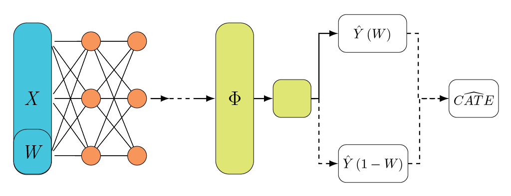

Figure 1: Estimating CATE Using Deep Neural Networks

### 4.1 Neural network architecture, model training, and treatment effects estimation

Deep neural networks (that is, deep learning) can be employed to estimate the CATEs and PATT from datasets by using Python libraries such as Keras3 (Chollet et al. 2015) and TensorFlow (Abadi et al. 2015). The deep learning estimation procedure for causal inference consists of four steps. First, after loading and splitting their dataset into training and test sets, researchers need to build their neural network model for conducting the necessary estimation exercise. This entails defining their deep neural network architecture which involves specifying layers, activation functions, and the overall structure. Second, once the model is defined, researchers must compile it by specifying an optimizer for updating the model’s weights to minimize the loss, define a loss function, and choose metrics.

While numerous optimization algorithms such as Adam, Stochastic Gradient Descent, AdaGrad, or RMSprop can be employed to update the model’s weights for loss minimization, the applications presented below focus on using Adam (Adaptive Moment Estimation) for deep learning estimation of the CATE and PATT. Adam is an adaptive learning rate algorithm that leverages past gradient information to accelerate convergence, handle sparse gradients, dynamically adjust the learning rate for each individual parameter within a model, and minimize hyperparameter tuning. Apart from choosing an optimization algorithm, a loss function appropriate for the task must be defined, and metrics must be chosen to monitor during training and evaluation.

Third, after compiling the model, researchers need to train the model. This is implemented by fitting the model to the training data which involves setting the number of times the model iterates over the entire training dataset (denoted as `epochs`), choosing the number of samples processed before updating model weights (that is, `batch_size`), and setting the proportion of the training data used for validation during training via `validation_split`. Fourth, after training the model, researchers can proceed to estimate causal effects such as CATEs in the held-out test data. Since the loss function only minimizes the factual error to estimate $\hat{Y}$ (this is because we only observe one potential outcome for each unit), one has to artificially toggle the treatment to obtain $\hat{Y}(1)$ and $\hat{Y}(0)$ for each unit. After doing so, one can plug in the predictions to calculate the predicted CATEs for the meta-learner model of interest. To save space, we discuss the procedure and code for estimating the PATT in settings with treatment noncompliance in Section 7 below.

## 5 Loading the DeepLearningCausal package and datasets

### 5.1 Functions, Reticulate, TensorFlow and Keras

Estimating the CATEs and PATT via deep neural networks requires the use of libraries in Python while also simultaneously using R code and modules. Our DeepLearningCausal package allows users to leverage Python libraries within the R programming environment and seamlessly use Python’s robust deep learning ecosystem in their R session. To see how, users need to first install the DeepLearningCausal package from CRAN via `install.packages("DeepLearningCausal")`, and from its GitHub repository (hknd23/DeepLearningCausal). The DeepLearningCausal package automatically installs the reticulate R package that facilitates interoperability between Python and R, and it also automatically installs the TensorFlow and Keras3 R packages as dependencies.

TensorFlow and Keras3 allow for functions from the deep learning Python libraries TensorFlow and Keras(3.0) to work in tandem with R. However, given that the R packages only provide the interface, users must have the Python version of TensorFlow and Keras installed for the packages to work properly through reticulate. Hence, to streamline the installation process, users must call the function `python_ready()` to create a virtual environment for Python, and check for as well as install the necessary Python versions of the packages (TensorFlow, Keras3, NumPy). `python_ready()` thus ensures that both the R and Python versions of TensorFlow and Keras3 are installed. After installation of our package from CRAN, users can import the package by calling `library(DeepLearningCausal)` to import the functions in the package. Table 1 lists the functions in DeepLearningCausal:

Table 1: Brief description of functions in **DeepLearningCausal**

| Function | Description |
| --- | --- |
| `metalearner_deeplearning()` | Deep neural network estimation of CATEs for S, T, X, and R-learner using reticulate, tensorflow and keras3 |
| `pattc_deeplearning()` | Deep neural network estimation of PATT using reticulate, tensorflow and keras3 |
| `conformal_plot()` | Conformal prediction for inference of ITEs from S and T-learner |
| `hte_plot()` | Heterogeneous Treatment Effects plot from meta-learner and PATT-C models |
| `metalearner_ensemble()` | Weighted ensemble learning estimation of CATEs for S, T, X, and R-learner using Super Learner (GitHub repo) |
| `metalearner_neural()` | Deep neural network estimation of CATEs for S, T, X, and R-learner using R neural net (GitHub repo) |
| `pattc_ensemble()` | Weighted ensemble learning estimation of PATT using Super Learner (GitHub repo) |
| `pattc_neural()` | Deep neural network estimation of PATT using R neural net (GitHub repo) |

### 5.2 Datasets

```r
data("exp_data_full")
str(exp_data_full)
```

```
'data.frame':   514 obs. of  16 variables:
 $ strong_leader      : int  1 0 1 1 1 1 1 1 1 0 ...
 $ support_war        : int  0 1 0 1 1 0 1 1 1 1 ...
 $ compliance         : int  1 0 1 1 0 1 0 0 1 0 ...
 $ female             : num  1 0 1 1 1 0 1 0 1 1 ...
 $ age                : int  38 28 25 32 21 60 38 44 31 20 ...
 $ income             : int  7 2 5 7 9 7 4 3 4 2 ...
 $ religion           : int  1 6 1 9 1 6 5 6 6 9 ...
 $ hindu              : int  0 1 0 0 0 1 0 1 1 0 ...
 $ practicing_religion: int  4 1 1 1 4 3 2 1 1 1 ...
 $ education          : int  4 3 4 4 8 7 4 3 4 4 ...
 $ political_ideology : int  4 5 6 10 5 3 3 10 9 5 ...
 $ employment         : int  1 6 2 2 5 1 1 2 3 6 ...
 $ employed           : int  1 0 0 0 0 1 1 0 0 0 ...
 $ marital_status     : int  6 6 6 6 6 1 1 1 1 6 ...
 $ married            : int  0 0 0 0 0 1 1 1 1 0 ...
 $ job_loss           : int  1 1 4 1 1 1 4 4 2 1 ...
```

```r
data("pop_data_full")
str(pop_data_full)
```

```
'data.frame':   11813 obs. of  17 variables:
 $ strong_leader      : num  0 0 NA 0 0 NA 1 0 0 1 ...
 $ support_war        : int  NA NA NA NA NA NA NA NA NA NA ...
 $ compliance         : int  0 0 0 0 0 0 1 0 0 1 ...
 $ female             : num  0 1 0 1 1 0 1 0 0 0 ...
 $ age                : int  48 38 42 26 39 24 28 20 42 68 ...
 $ income             : int  3 6 3 2 4 3 4 4 4 3 ...
 $ religion           : num  31 31 31 31 31 31 31 31 31 31 ...
 $ hindu              : int  1 1 1 1 1 1 1 1 1 1 ...
 $ practicing_religion: int  2 2 4 2 2 2 3 4 4 2 ...
 $ education          : int  2 2 6 1 1 1 8 8 7 7 ...
 $ political_ideology : int  5 5 5 5 5 -1 5 5 5 5 ...
 $ employment         : int  3 6 1 2 6 3 6 7 1 5 ...
 $ employed           : int  1 0 1 1 0 1 0 0 1 0 ...
 $ marital_status     : int  1 1 1 1 1 6 1 6 1 1 ...
 $ married            : int  1 1 1 1 1 0 1 0 1 1 ...
 $ job_loss           : int  NA NA NA NA NA NA NA NA NA NA ...
 $ year               : int  2001 2001 2001 2001 2001 2001 2001 2001 2001 2001 ...
```

After random assignment to treatment or control, respondents are asked whether or not they support fighting a war against a foreign adversary. This generates the binary *support war* outcome measure. We record the vignette screen time latency and conduct factual manipulation checks to generate the binary *compliance* variable coded as 1 for respondents who understood and followed the instructions associated with the *strong leader* treatment and thus complied with this treatment; it is coded 0 for noncompliers. The survey experiment sample also includes confounders that operationalize the respondents’ demographic features, dispositional traits, and attitudinal characteristics.

The second dataset in the package (`pop_data_full`) is the commensurate representative population-level World Values Survey response data from India for 1995, 2001, 2006, 2012, and 2022. This survey response data includes the binary *support war* outcome variable that mirrors the binary “support war” outcome measure in the India survey experiment sample. It also includes responses to a question about the respondents’ preference for a *strong leader* that is compatible with the “strong leader” treatment variable in the survey experiment sample. The binary *compliance* indicator in this data is 1 for those who responded to the strong leader preference question as this indicates compliance with the treatment proxy; it is 0 for respondents who did *not* answer this question as non-response indicates treatment noncompliance. The population-level survey response data include the same demographic, dispositional, and attitudinal covariates of respondents included in the survey experiment sample.

The following formula that specifies each model’s (S-Learner, T-Learner, X-Learner, R-Learner, PATT-C) outcome measure *support war* and list of covariates drawn from the package’s two example datasets helps us illustrate the applicability of the functions in DeepLearningCausal:

```r
response_formula <- support_war ~ age + female + education + income + employed +
                                  job_loss + hindu + political_ideology
```

## 6 Deep learning estimation of meta-learner models

### 6.1 Deep neural networks for meta-learners

After initializing Python and setting up the virtual environment with `python_ready()`, the `metalearner_deeplearning()` function in DeepLearningCausal enables users to use TensorFlow and Keras3 to estimate CATEs from the S, T, X, and R-learner models. To save space, we focus on demonstrating below the applicability of the `metalearner_deeplearning()` function for the S-learner model by using the survey experiment dataset in our package. We also briefly present below some results from the deep learning-estimated T and X-learner models. More details about the procedure and results from the deep learning-estimated T, X and R-learner models by calling the `metalearner_deeplearning()` function are provided in the package’s GitHub repository.

The arguments to reconfigure and train the deep neural networks for estimation include the optimization `algorithm` (options include “adam”, “adagrad”, “rmsprop”, “sgd”), the number of `epochs` or iterations for a full pass of the data through the network to update weights, the size of each batch (`batch_size`) to split the training data, and `verbose` for monitoring the training progress. The arguments for metrics evaluation include `metrics = "accuracy"` for classification models and `metrics = "mean squared error"` for regression models. Arguments to specify the tuning of hyperparameters to monitor and mitigate overfitting include: `validation_split` that checks for overfitting, `patience` that stops the model early if overfitting is detected, and `dropout_rate` that mitigates overfitting to specify the proportion of neurons in each layer that can be dropped during training.

Next, the `plot(slearner_deep$m1_model_history[[1]])` in our DeepCausalLearning package allows users to illustrate the trace plot of the loss function and accuracy plots from the S-learner model. Moreover, as illustrated below, if the validation split is specified, then the trace and accuracy plots obtained from `plot(slearner_deep$m1_model_history[[1]])` will help users visualize how well the deep neural network model is learning and identifying potential problems such as overfitting for both the training and validation datasets:

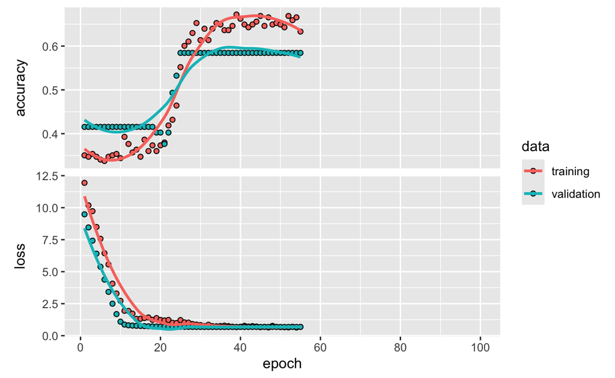

Figure 2: Accuracy Plot and Trace Plot of the Loss Function for the S-Learner

```r
plot(slearner_deep$ml_model_history[[1]])
```

The bottom half of Figure 2 illustrates the trace plot of the loss function for the S-learner. This plot shows model performance through loss after each epoch. The y-axis of the plot shows the loss value (e.g., mean squared error, cross-entropy) while the x-axis indicates the training progress (e.g., epochs, iterations). The said trace plot figure reveals that the loss decreases steadily and smoothly on *both* the training and validation sets before flattening out. This means that the neural network model that we trained is learning effectively and generalizing well to new data.

### 6.2 CATEs, Conformal Inference, Heterogeneous Treatment Effects

Users can view the results of their deep neural network-estimated S and T-learner with `print(slearner_deep)` and `print(tlearner_deep)` respectively:

```
Method:
Deep Learning  S.Learner
Formula:
support_war ~ age + female + education + income + employed +      job_loss + hindu + political_ideology
Treatment Variable:  strong_leader
CATEs percentiles:
          10%           25%           50%           75%           90%
-0.0016767383 -0.0009825230 -0.0009157658 -0.0009118319 -0.0009078503
```

```
Method:
Deep Learning  T.Learner
Formula:
support_war ~ age + female + education + income + employed +      job_loss + hindu + political_ideology
Treatment Variable:  strong_leader
CATEs percentiles:
        10%         25%         50%         75%         90%
-0.25745040 -0.17228007 -0.05352932  0.02411348  0.05582668
```

The reported results provide information about the estimated CATE percentiles from the meta-learner model of interest. Next, the `conformal_plot()` function in DeepLearningCausal implements the conformal prediction framework to conduct direct inference of individual treatment effects (ITEs) obtained from the deep learning-estimated S and T-learner models. To see how, first note that individual treatment effects (ITEs) from the S-learner and T-learner are calculated as the difference between a subject’s predicted outcome with and without a specific treatment.

The conformal intervals for the deep learning S and T-learner are generated directly within the `metalearner_deeplearning()` function when the argument `conformal = TRUE` is specified. This is displayed below for just the S-learner to save space:

```r
slearner_deep <- metalearner_deeplearning(... , meta.learner.type = "S.Learner", ..., conformal = TRUE,
                                          alpha = 0.1, calib_frac = 0.5, prob_bound = TRUE,
                                          ... , seed = 1234)
```

Setting `conformal = TRUE` constructs uncertainty intervals around each estimated individual treatment effect (ITE). The argument `alpha = 0.1` specifies the miscoverage rate, corresponding to approximately 90% nominal coverage. `calib_frac = 0.5` divides the test sample into two parts: one is used for model prediction, and the other serves as a calibration set to compute residuals that quantify the typical deviation between model predictions and observed outcomes in finite samples.

The conformal adjustment is then determined by the *weighted quantile* of these residuals, where the weights are derived from the estimated propensity scores to correct for treatment–control imbalance. Setting `prob_bound = TRUE` ensures that the predicted probabilities and resulting conformal intervals are restricted to the [-1, 1] feasible range for binary outcomes. After estimation, the function stores the conformal intervals in `conformal` (S-learner) and `conformal` (T-learner) which can be visualized using:

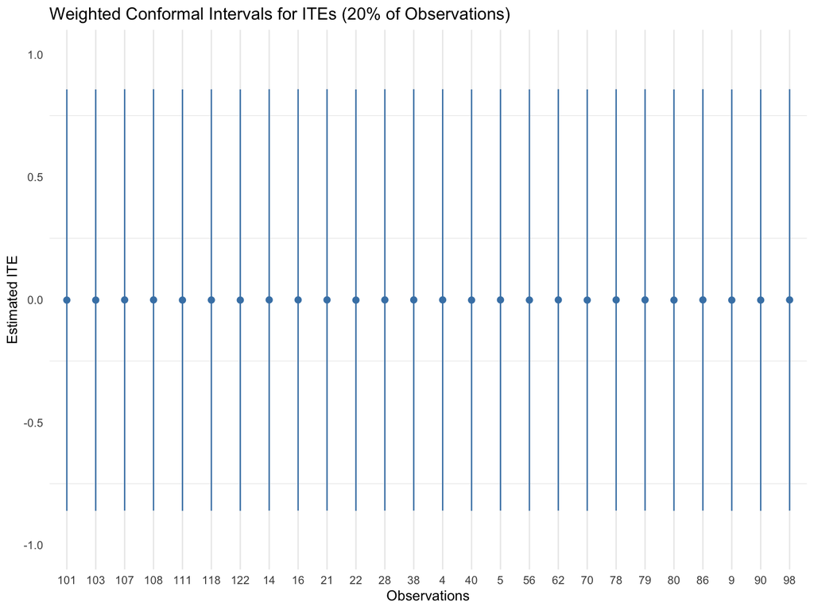

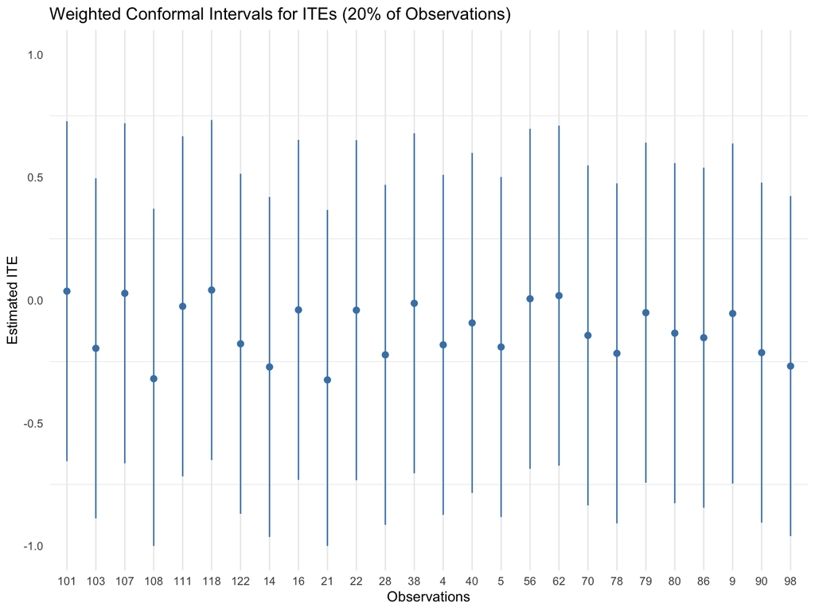

Figure 3: Conformal Predictions from Deep Neural Network-Based Meta Learners

```r
conformal_plot(slearner_deep, binary.outcome = TRUE, prop = .2, seed = 1234)
conformal_plot(tlearner_deep, binary.outcome = TRUE, prop = .2, seed = 1234)
```

Unlike the S-learner, which estimates both potential outcomes within a single network, the T-learner fits separate models for the treated and control groups. As a result, its conformal intervals often appear narrower and more heterogeneous across observations, reflecting that uncertainty is estimated conditional on treatment status rather than pooled across all units. By contrast, the S-learner tends to yield more conservative coverage due to shared outcome modeling, while the T-learner captures finer treatment-specific variation in individual effects.

Apart from the S- and T-learner models, our package permits users to customize their deep neural network architecture for deep learning estimation of the X- and R-learner models using reticulate, TensorFlow, and Keras3. The procedure and results for the R-learner are presented in the package’s GitHub repository. After the X-learner model is estimated via their customized deep neural network architecture, users can view the model’s results with `print(xlearner_deep)`:

```r
print(xlearner_deep)
```

```
Method:
Deep Learning  X.Learner
Formula:
support_war ~ age + female + education + income + employed +      job_loss + hindu + political_ideology
Treatment Variable:  strong_leader
CATEs percentiles:
      10%       25%       50%       75%       90%
0.2012221 0.2012221 0.2012221 0.2012221 0.2012221
```

These results report the deep neural network-estimated CATE percentiles from the X-learner model. The conformal prediction framework described earlier can also be employed to compute and illustrate conformal prediction (CP) intervals for individual treatment effects (ITEs) estimated from the two pseudo-outcome meta-learner models: the X and R-learner. The procedure as well as code for extracting CP intervals for the estimated ITEs from pseudo-outcome meta-learners have been developed and described by Alaa et al. (2023) and are thus not summarized here to save space.

As such, the estimated CATEs from all the meta-learner models in our package are stored in the element `CATEs`. The DNN-estimated CATEs from the (i) X-learner stored in `CATEs` can be called with `xlearner_deep$CATEs`, (ii) S-learner can be called with `slearner_deep$CATEs`, and (iii) T-learner can be called with `tlearner_deep$CATEs`. Users can thus employ the stored CATEs from all these three DNN-estimated meta-learner models (and the R-learner model) to illustrate and analyze treatment effect heterogeneity across distinct subgroups in their sample by using the `hte_plot()` function in our package. As displayed below, the `hte_plot()` function gives users the flexibility to enter any number of covariates for which she or he would like to assess heterogeneous treatment effects.

```r
hte_plot(slearner_deep, selected_vars = c( "employed", "female", "political_ideology"),
         cut_points = c(.5,.5,5),  custom_labels= c( "Employed", "Unemployed",
                      "Male", "Female", "Centrist", "Right-wing Partisan"))
```

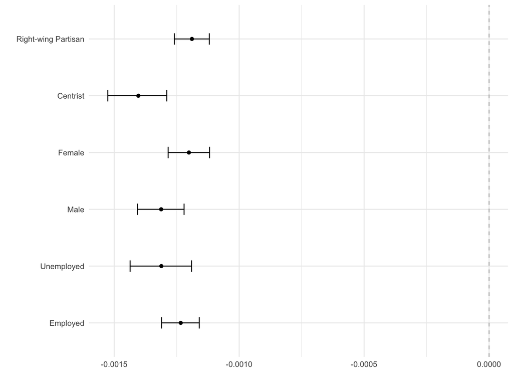

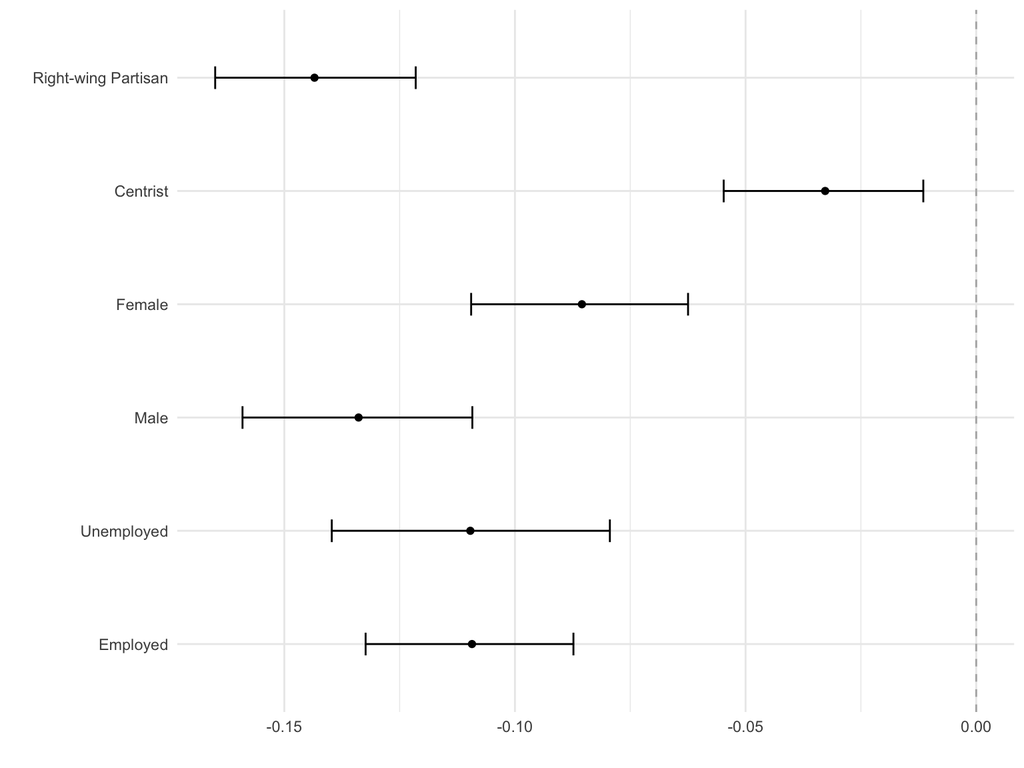

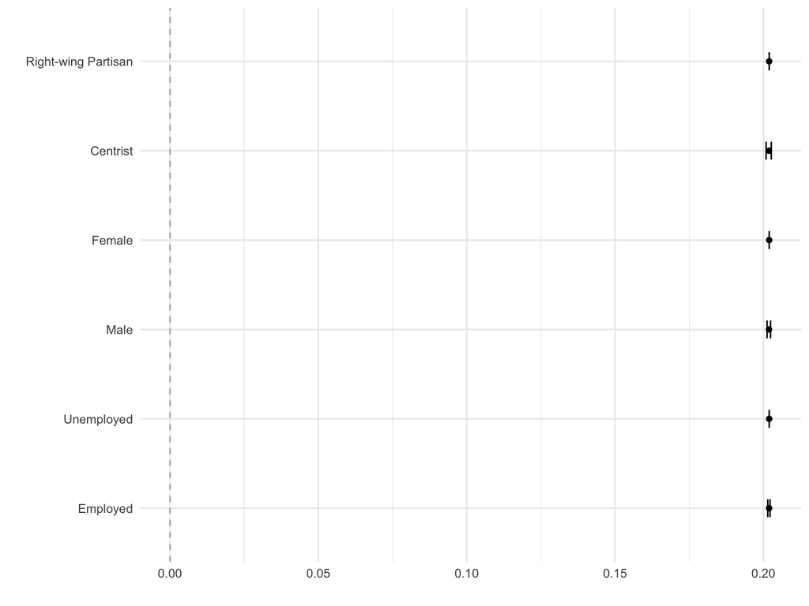

Figure 4: HTEs from Deep Neural Network-Based Meta Learners

### 6.3 Comparing Meta-Learner Treatment Effects and Supplementary Analysis

The DeepLearningCausal package also enables users to plot the histograms and pairwise correlations of the estimated individual treatment effects from the deep neural network-estimated meta-learner models by using the psych package’s `pairs.panels()`:

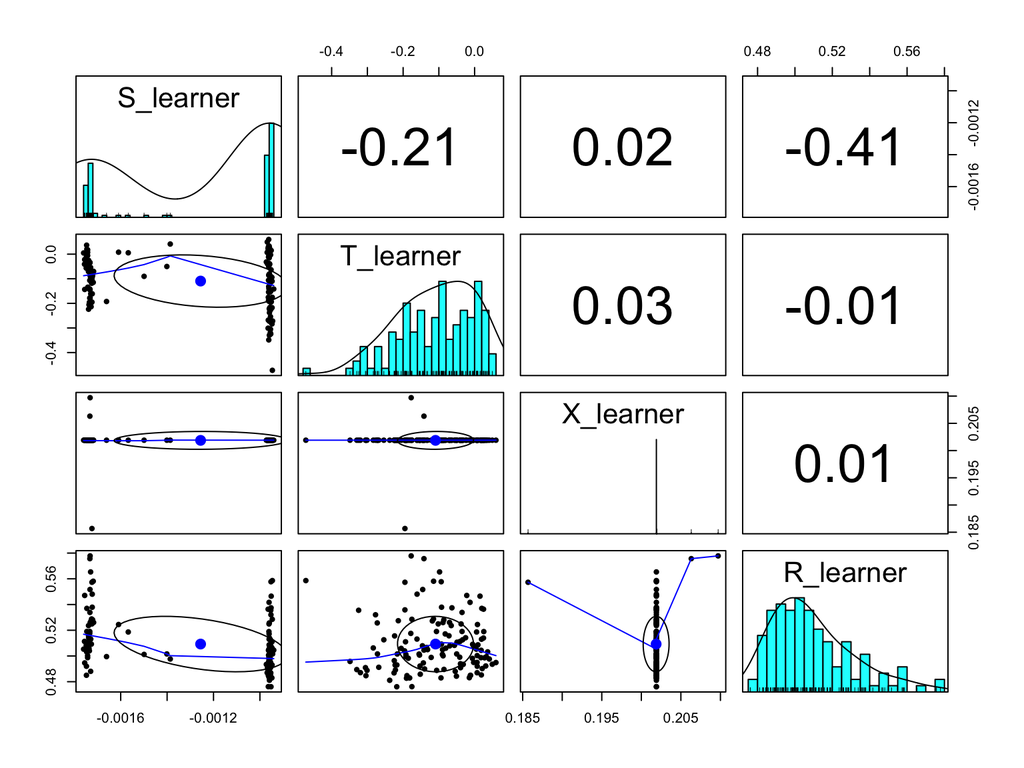

Figure 5: Treatment Effects Distribution and Correlations: Deep Neural Network-based Meta Learners

```r
allCATEs_deep <- data.frame("S_learner" = slearner_deep$CATEs,
                            "T_learner" = tlearner_deep$CATEs,
                            "X_learner" = xlearner_deep$CATEs,
                            "R_learner" = rlearner_deep$CATEs)
psych::pairs.panels(allCATEs_deep, breaks = 30)
```

## 7 Deep learning for estimating PATT with treatment noncompliance

### 7.1 Deep neural networks for estimating the PATT

The `pattc_deeplearning()` function in the DeepLearningCausal package enables users to estimate the PATT by employing the survey experiment data and the population-level survey data in our package. To start with, the argument `exp.data = exp_data_full` in the aforementioned function specifies the data input for the experimental sample which serves as the training data. `pop.data = pop_data_full` is the data input for the representative population-level data (this is the World Values Survey in the package) which serves as the test data. `exp.data = exp_data_full` and `pop.data = pop_data_full` are both employed to estimate the PATT in settings with treatment noncompliance.

The argument `response.formula = response_formula` permits users to specify the outcome variable (e.g., *support war*) and the confounders in the PATT-C model. `treat.var` and `compl.var` allow users to specify the treatment variable and the compliance variable, respectively.

Users can also specify the arguments for the response model based on the outcome variable. For a binary outcome variable, the activation function of the response model’s output layer is `response.output_activation` which is set to “sigmoid”. The argument `response.output_units` is the number of units for the response model’s output layer. Next, users can define the response model’s loss function as `response.loss = "binary_crossentropy"` for classification and `response.loss = "mean_squared_error"` for regression. The argument `compl.algorithm` and `response.algorithm` denote the optimization algorithms (e.g., “adam”, “adagrad”, “rmsprop”) for the compliance and response models, respectively.

`compl.epoch` and `response.epoch` denote iterations of the full pass of the data through the network to update weights for the compliance and response models, respectively. The argument `batch_size` permits users to split the training data, while `verbose` allows users to monitor the training progress. The arguments for the evaluation metrics are `response.metrics = "accuracy"` for when the response model is a classification model and `response.metrics = "mean_squared_error"` for a regression model. Arguments that specify the tuning of hyperparameters to monitor and mitigate overfitting for deep neural networks when estimating the PATT are `compl.validation_split` for the compliance model, and `response.validation_split` for the response model. Users can specify `compl.patience` and `response.patience` to stop the model early if overfitting is detected for the compliance and response models. `compl.dropout_rate` permits users to set the proportion of neurons in each layer that can be dropped during training of the compliance model to mitigate overfitting. The argument `nboot = 1000` sets the number of bootstrap samples to 1,000. Finally, `plot(deeppattc$complier_history)` and `plot(deeppattc$response_history)` can be employed to illustrate the trace plots of the loss and metric functions of the complier and response models used for estimating the PATT. This enables users to assess whether their deep neural network architecture is learning and identifying overfitting when estimating PATT in data with treatment noncompliance.

Once the deep neural networks are trained on the experimental data, users can call `deeppattc$pop_counterfactual` to extract the predicted probabilities of the outcome measure for population treatment compliers *if* they are all in the treated group (the counterfactual treated group) and *if* they are all in the control group (the counterfactual control group). They can then use `plot(deeppattc)` to illustrate the distribution of these predicted probabilities of the outcome measure for population compliers in the counterfactual treated group (blue histogram) and counterfactual control group (red histogram):

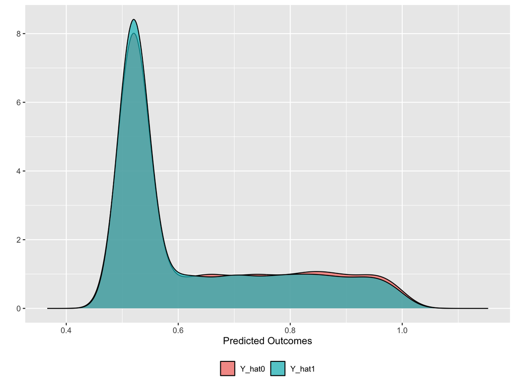

Figure 6: Counterfactual Predictions Deep Learning PATT-C

This figure indicates that the share of population compliers in the counterfactual treated group who support war is not different than their peers in the counterfactual control group. The predicted probabilities of the outcomes obtained from this exercise can also be employed for additional analyses, such as identifying members in the target population who are most receptive to the treatment.

### 7.2 Heterogeneous Treatment Effects and supplementary analysis

Our DeepLearningCausal package also enables users to extract and illustrate heterogeneous treatment effects for specified subgroups in the target population once the PATT has been estimated from datasets with treatment noncompliance using their deep neural network architecture. Heterogeneous treatment effects are estimated by taking differences across response surfaces for a given covariate, and response surfaces are estimated with neural network-based mean predictions when deep neural networks are employed for estimating the PATT. Users can call the `hte_plot()` function to extract and illustrate the heterogeneous treatment effects for the deep neural network-estimated PATT-C model. The HTE plot is shown below for the *support war* outcome measure for the subgroups listed earlier:

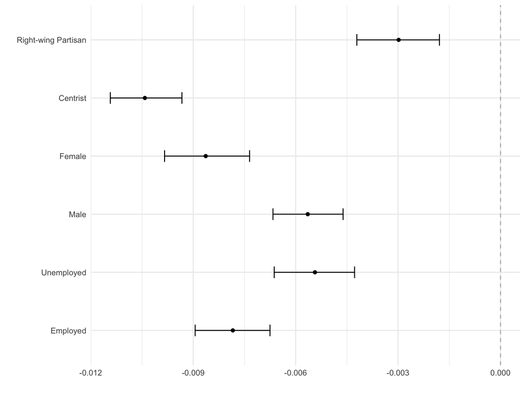

Figure 7: HTEs for Selected Covariates of Interest

```r
hte_plot(deeppattc, selected_vars = c( "employed", "female", "political_ideology"),
         cut_points = c(.5,.5,5),  custom_labels= c( "Employed", "Unemployed",
                                                     "Male", "Female", "Centrist",
                                                     "Right-wing Partisan"))
```

In addition to deep learning estimation of the PATT in settings with treatment noncompliance, our DeepLearningCausal package also allows users to employ the R neuralnet package for estimating the PATT (from the PATT-C model) via deep neural networks with `pattc_neural()`. Additionally, the `pattc_ensemble()` function in DeepLearningCausal permits users to estimate the PATT from datasets that exhibit treatment noncompliance by using weighted ensemble learning from `library(SuperLearner)` that focuses on four candidate machine learning algorithms mentioned earlier. The procedure for estimating the PATT in settings with treatment noncompliance via deep neural networks (from R neuralnet) and weighted ensemble learning using the super learner is described in our package’s GitHub repository (hknd23/DeepLearningCausal).

## 8 Conclusion

The rapid surge in research on causal machine learning has led to the development of statistical software packages that enable users to employ conventional machine learning, weighted ensemble learning or targeted learning to estimate a wide variety of causal models (e.g., Laan and Rose 2011; Nie and Wager 2021; Hu and Ji 2022; Knaus 2022; Zhao and Liu 2023). More recent research on causal inference has, however, sought to demonstrate how deep causal learning, which leverages deep neural networks, can address challenges stemming from high-dimensional data, unobserved confounders, and selection bias (Goodfellow et al. 2016; Koch et al. 2024; Li et al. 2024). Yet barring some open-source Python code that introduces deep learning for causal inference (Koch et al. 2024), there is, to our knowledge, no R package that allows users to employ deep learning methods for estimating treatment effects in settings with noncompliance.

Our R package addresses this lacuna by offering functions that enable the use of deep learning—deep neural networks—to estimate the meta-learner CATEs in samples and the PATT from a newly developed causal estimand that addresses treatment noncompliance (Künzel et al. 2019; Ottoboni and Populos 2020). Another feature of our package is that it enables users to import Python’s deep learning modules directly into their R session to construct and customize their deep neural network architecture for estimating treatment effects. It also permits users to apply the conformal prediction (CP) procedure to generate predictive intervals for ITEs from a set of conditional mean regression meta-learner models.

Future work can build on the general deep neural network architecture for causal inference in numerous ways. For instance, R packages can be developed that allow users to employ specific deep neural network models such as Convolutional Neural Networks, Recurrent Neural Networks, Variational Autoencoders, and Conditional Generative Adversarial Networks. These specific models offer several benefits for causal inference such as learning non-linear relationships between features and counterfactual outcomes, imputation of missing counterfactual outcomes, learning latent representations of data, predicting the conditional outcome and propensity score, and extending causal inference to text data, networks, and images. The deep learning-estimated causal models in our R package can be applied to high-dimensional data, large-scale RCTs conducted for target populations, and observational data with unknown interventions and long-range temporal dependencies. Doing so will expand the application of the causal models in the package across several fields that employ randomized trials, panel data, or high-dimensional observational data.

### 8.1 CRAN packages used

DeepLearningCausal, reticulate, tensorflow, keras3, DoubleML, lmtp, CIMTx, causaloptim, htetree, twangContinuous, SuperLearner, psych

### 8.2 CRAN Task Views implied by cited packages

Bayesian, CausalInference, Cluster, Econometrics, HighPerformanceComputing, MachineLearning, ModelDeployment, NumericalMathematics, Psychometrics

M. Abadi et al. TensorFlow: Large-scale machine learning on heterogeneous systems. 2015. URL https://www.tensorflow.org/. accessed 2025-11-05.

A. Alaa, Z. Ahmed and M. van der Laan. Conformal meta-learners for predictive inference of individual treatment effects. *Proceedings of the 37th Conference on Neural Information Processing Systems*, 48: 1–22, 2023. URL https://proceedings.neurips.cc/paper_files/paper/2023/file/94ab02a30b0e4a692a42ccd0b4c55399-Paper-Conference.pdf.

A. Alaa and M. Van Der Schaar. Limits of estimating heterogeneous treatment effects: Guidelines for practical algorithm design. *Proceedings of the 35th International Conference on Machine Learning*, 80: 129–138, 2018. URL https://proceedings.mlr.press/v80/alaa18a.html.

J. J. Allaire and Y. Tang. *Tensorflow: R interface to ’TensorFlow’.* 2024. URL https://CRAN.R-project.org/package=tensorflow. R package version 2.16.0.

S. Athey and G. W. Imbens. Recursive partitioning for heterogeneous causal effects. *Proceedings of the National Academy of Sciences*, 113(27): 7353–7360, 2016. URL https://doi.org/10.1073/pnas.1510489113.

P. Bach, M. S. Kurz, V. Chernozhukov, M. Spindler and S. Klaassen. DoubleML: An object-oriented implementation of double machine learning in R. *Journal of Statistical Software*, 108(3): 1–56, 2024. URL https://doi.org/10.18637/jss.v108.i03.

L. B. Balzer, M. L. Petersen and M. J. van der Laan. Targeted estimation and inference for the sample average treatment effect in trials with and without pair-matching. *Statistics in Medicine*, 35(21): 3717–3732, 2016. URL https://doi.org/10.1002/sim.6965.

K. Battocchi, E. Dillon, M. Hei, G. Lewis, P. Oka, M. Oprescu and V. Syrgkanis. EconML: A Python Package for ML-Based Heterogeneous Treatment Effects Estimation. 2019. URL https://github.com/py-why/EconML. Version 0.x.

V. Chernozhukov, D. Chetverikov, M. Demirer, E. Duflo, C. Hansen, W. Newey and J. Robins. Double/debiased machine learning for treatment and structural parameters. *The Econometrics Journal*, 21(1): C1–C68, 2018. URL https://doi.org/10.1111/ectj.12097.

F. Chollet et al. Keras. 2015. URL https://keras.io. accessed 2025-11-05.

D. Coffman and B. Griffin. *twangContinuous: Toolkit for weighting and analysis of nonequivalent groups - continuous exposures.* 2021. URL https://CRAN.R-project.org/package=twangContinuous. R package version 1.0.0.

I. Dı́az, N. Williams, K. Hoffman and E. Schneck. Non-parametric causal effects based on longitudinal modified treatment policies. *Journal of the American Statistical Association*, 2021. URL https://doi.org/10.1080/01621459.2021.1955691.

M. Farrell, T. Liang and S. Misra. Deep neural networks for estimation and inference. *Econometrica*, 89(1): 181–213, 2021. URL https://doi.org/10.3982/ECTA16901.

A. N. Glynn and K. M. Quinn. An introduction to the augmented inverse propensity weighted estimator. *Political analysis*, 18(1): 36–56, 2010. URL https://doi.org/10.1093/pan/mpp036.

I. Goodfellow, Y. Bengio and A. Courville. *Deep learning.* Cambridge, MA: MIT Press, 2016. URL https://mitpress.mit.edu/9780262035613/deep-learning/.

E. Hartman, R. Grieve, R. Ramsahai and J. S. Sekhon. From SATE to PATT: Combining experimental with observational studies to estimate population treatment effects. *Journal of Royal Statistical Society Series A. Stat. Soc*, 178(3): 757–778, 2015. URL https://doi.org/10.1111/rssa.12094.

J. Hill. Bayesian nonparametric modeling for causal inference. *Computational and Graphical Statistics*, 20(1): 217–240, 2011. URL https://doi.org/10.1198/jcgs.2010.08162.

L. Hu and J. Ji. CIMTx: An R package for causal inference with multiple treatments using observational data. *R Journal*, 14(3): 213–230, 2022. URL https://journal.r-project.org/articles/RJ-2022-058/.

L. Hu, J. Ji and F. Li. Estimating heterogeneous survival treatment effect in observational data using machine learning. *Statistics in Medicine*, 40(21): 4691–4713, 2021. URL https://doi.org/10.1002/sim.9090.

G. W. Imbens and D. Rubin. *Causal inference for statistics, social, and biomedical sciences: An introduction.* Cambridge, NY: Cambridge University Press, 2015. URL https://doi.org/10.1017/CBO9781139025751.

F. Johansson, U. Shalit and D. Sontag. Learning representations for counterfactual inference. in. *Proceedings of the 35th International Conference on Machine Learning*, 48: 3020–3029, 2016. URL https://dl.acm.org/doi/10.5555/3045390.3045708.

G. Jonzon, M. Sachs and E. Gabriel. Accessible computation of tight symbolic bounds on causal effects using an intuitive graphical interface. *R Journal*, 15(4): 53–68, 2023. URL https://journal.r-project.org/articles/RJ-2023-083/.

T. Kalinowski, J. J. Allaire and F. Chollet. *keras3: R interface to ’Keras’.* 2025. URL https://CRAN.R-project.org/package=keras3. R package version 1.4.0.

M. Knaus. Double machine learning-based program evaluation under unconfoundedness. *The Econometrics Journal*, 25(3): 602–627, 2022. URL https://doi.org/10.1093/ectj/utac015.

B. J. Koch, T. Sainburg, P. E. Geraldo, S. Jiang, Y. Sun and J. G. Foster. A primer on deep learning for causal inference. *Sociological Methods and Research*, 54(2): 1–51, 2024. URL https://doi.org/10.1177/00491241241234866.

S. Künzel, J. Sekhon, P. Bickel and B. Yu. Metalearners for estimating heterogeneous treatment effects using machine learning. *Proceedings of the National Academy of Sciences*, 116(1): 4156–4165, 2019. URL https://doi.org/10.1073/pnas.1804597116.

M. J. van der Laan and S. Rose. *Targeted learning: Causal inference for observational and experimental data.* Springer, NY: Springer Nature, 2011. URL https://link.springer.com/book/10.1007/978-1-4419-9782-1.

L. Lei and E. Candès. Conformal inference of counterfactuals and individual treatment effects. *Journal of the Royal Statistical Society Series B: Statistical Methodology*, 83(5): 911–938, 2021. URL https://doi.org/10.1111/rssb.12445.

Z. Li, X. Guo and S. Qiang. A survey of deep causal models and their industrial applications. *Artificial Intelligence Review*, 57(1): 298, 2024. URL https://doi.org/10.1007/s10462-024-10886-0.

X. Nie and S. Wager. Quasi-oracle estimation of heterogeneous treatment effects. *Biometrika*, 108(2): 299–319, 2021. URL https://doi.org/10.1093/biomet/asaa076.

G. Okasa. Meta-learners for estimation of causal effects: Finite sample cross-fit performance. *arXiv preprint arXiv:2201.12692*, 2022. URL https://doi.org/10.48550/arXiv.2201.12692.

K. N. Ottoboni and J. V. Populos. Estimating population average treatment effects from experiments with noncompliance. *Journal of Causal Inference*, 8: 108–130, 2020. URL https://doi.org/10.1515/jci-2018-0035.

J. Pearl. *Causality.* Cambridge, NY: Cambridge University Press, 2009. URL https://doi.org/10.1017/CBO9780511803161.

S. Powers, J. Qian, K. Jung, A. Schuler, N. Shah, T. Hastie and R. Tibshirani. Some methods for heterogeneous treatment effect estimation in high dimensions. *Statistics in Medicine*, 37(11): 671–679, 2018. URL https://doi.org/10.1002/sim.7623.

M. Ratkovic. *SVMMatch: Causal effect estimation and diagnostics with support vector machines.* 2015. URL https://CRAN.R-project.org/package=SVMMatch. R package version 1.1.

M. S. Schuler and S. Rose. Targeted maximum likelihood estimation for causal inference in observational studies. *American Journal of Epidemiology*, 185(1): 65–73, 2019. URL https://doi.org/10.1093/aje/kww165.

S. Tikka. Identifying counterfactual queries with the R package cfid. *R Journal*, 15(2): 330–343, 2023. URL https://journal.r-project.org/articles/RJ-2023-053/.

K. Ushey, J. J. Allaire and Y. Tang. *Reticulate: Interface to ’Python’.* 2025. URL https://CRAN.R-project.org/package=reticulate. R package version 1.42.0.

A. Wager and S. Athey. Estimation and inference of heterogeneous treatment effects using random forests. *Journal of the American Statistical Association*, 113(523): 1228–1242, 2019. URL https://doi.org/10.1080/01621459.2017.1319839.

J. Xu, T. Shinkre and J. Brand. *Htetree: Causal inference with tree-based machine learning algorithms.* 2023. URL https://CRAN.R-project.org/package=htetree. R package version 0.1.18.

L. Yao, S. Li, Y. Li, M. Huai, J. Gao and A. Zhang. Representation learning for treatment effect estimation from observational data. *Advances In Neural Information Processing Systems*, 31(1): 2633–2643, 2018. URL https://doi.org/10.1002/sim.7623.

Y. Zhang, A. Bellot and M. Schaar. Learning overlapping representations for the estimation of individualized treatment effects. *Proceedings of the Twenty Third International Conference on Artificial Intelligence and Statistics*, 1005–1014, 2020. URL https://doi.org/10.48550/arXiv.2001.04754.

Z. Zhang, Z. Hu and C. Liu. Estimating the population average treatment effect in observational studies with choice-based sampling. *The International Journal of Biostatistics*, 15(1): 965–972, 2019. URL https://doi.org/10.1515/ijb-2018-0093.

Y. Zhao and Q. Liu. CausalML: Python package for causal inference machine learning. *SoftwareX*, 21: 101294, 2023. URL https://doi.org/10.1016/j.softx.2022.101294.